# Report of Experimental Research Designs

# One-way ANOVA (States)

My next test will be focused on understanding whether there is a statistically significant difference between the means (in the case of a parametric approach) or medians (in the case of a non-parametric approach) of post-movie tolerance in the three states. In this case I have one factor with three levels (Wisconsin, Iowa and Connecticut), so I’ll perform a one-way ANOVA. Let’s check the assumptions to see if I can use the parametric approach.

Assumptions:

1. Independence: The observations are obtained independently and randomly from the population. (True)
2. Normality: The outcome is normally distributed in each level of the factor.
3. Homoscedasticity: Variance of the outcome is the same in each level of the factor.

The first assumption is met as was stated at the beginning

To test the second assumption, let’s look at the histograms of the response variable in the three groups:

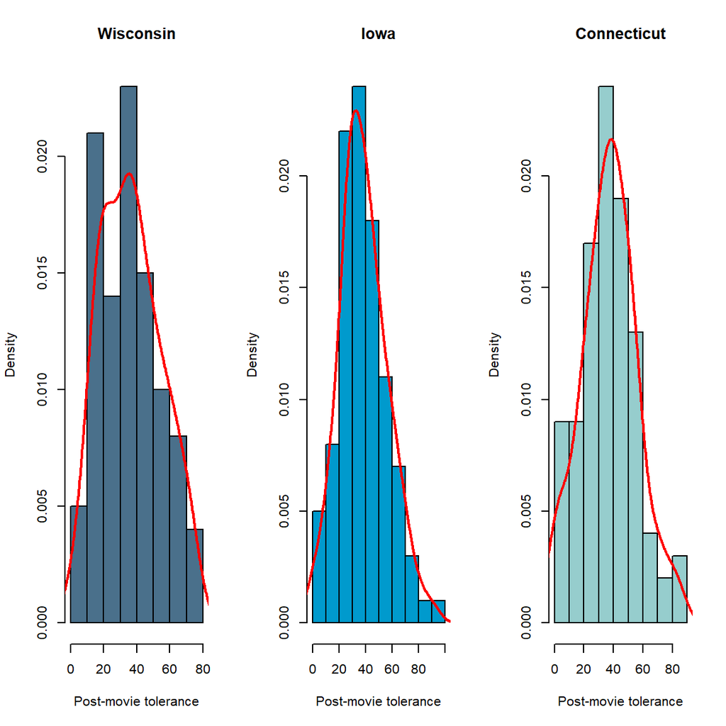

```r
par(mfrow=c(1,3))
hist(postmovie[state=="Wisconsin"],
     col="skyblue4",
     border = "black",
     prob = TRUE,
     xlab = "Post-movie tolerance",
     main = "Wisconsin",
     breaks = 10) # to decide bins
lines(density(postmovie[state == "Wisconsin"]), lwd = 2, col = "red") # add density

hist(postmovie[state=="Iowa"],
     col="deepskyblue3",
     border = "black",
     prob = TRUE,
     xlab = "Post-movie tolerance",
     main = "Iowa",
     breaks = 10) # to decide bins
lines(density(postmovie[state == "Iowa"]), lwd = 2, col = "red") # add density

hist(postmovie[state=="Connecticut"],
     col="paleturquoise3",
     border = "black",
     prob = TRUE,
     xlab = "Post-movie tolerance",
     main = "Connecticut",
     breaks = 10) # to decide bins
lines(density(postmovie[state == "Connecticut"]), lwd = 2, col = "red") # add density
```

The distributions seem approximately normal, but as usual let’s check this also with the shapiro test:

```r
shapiro.test(postmovie[state=="Connecticut"])
```

```
##
##  Shapiro-Wilk normality test
##
## data:  postmovie[state == "Connecticut"]
## W = 0.98607, p-value = 0.378
```

```r
shapiro.test(postmovie[state=="Iowa"])
```

```
##
##  Shapiro-Wilk normality test
##
## data:  postmovie[state == "Iowa"]
## W = 0.98787, p-value = 0.4986
```

```r
shapiro.test(postmovie[state=="Wisconsin"])
```

```
##
##  Shapiro-Wilk normality test
##
## data:  postmovie[state == "Wisconsin"]
## W = 0.97505, p-value = 0.05447
```

The response variable *postmovie* is normally distributed in the three groups.

```r
bartlett.test(postmovie, state)
```

```
##
##  Bartlett test of homogeneity of variances
##
## data:  postmovie and state
## Bartlett's K-squared = 0.15214, df = 2, p-value = 0.9268
```

p-value is > 0.05 so also the last assumption is met.

I can proceed with the classical ANOVA.

Hypothesis:

H0: mean(Connecticut) = mean(Iowa) = mean(Wisconsin) Ha: At least one mean is different.

Graphically:

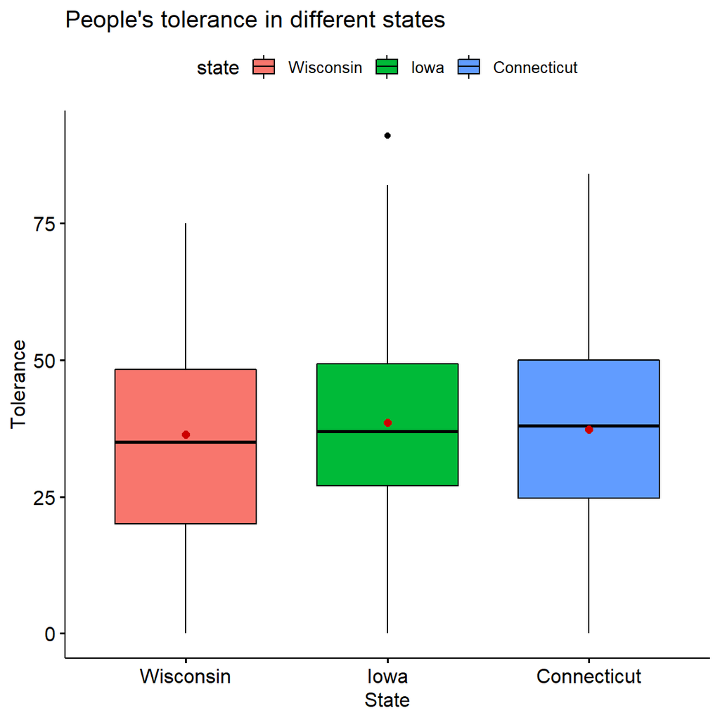

```r
ggboxplot(racism,
          x = "state",
          y = "postmovie",
          fill = "state",
          order = c("Wisconsin", "Iowa", "Connecticut"),
          ylab = "Tolerance",
          xlab = "State") +
  stat_summary(fun = "mean", geom = "point", color = "red3", size = 2)+
  ggtitle("People's tolerance in different states")
```

Let’s look at the summary of the variable *post-movie tolerance* in the three groups:

```r
state_summary <- racism %>%
  group_by(state) %>%
  summarise(sample_size = n(),
            mean = mean(postmovie),
            variance = var(postmovie),
            minimum = min(postmovie),
            lower_quartile = quantile(postmovie, 0.25),
            median = median(postmovie),
            upper_quartile = quantile (postmovie, 0.75),
            maximum = max(postmovie))

kable(state_summary) %>%
  kable_styling(font_size = ifelse(knitr:::is_latex_output(), 10, 16),
                latex_options = c("hold_position"))
```

| state | sample_size | mean | variance | minimum | lower_quartile | median | upper_quartile | maximum |
| --- | --- | --- | --- | --- | --- | --- | --- | --- |
| Connecticut | 100 | 37.35 | 346.7348 | 0 | 24.75 | 38 | 50.00 | 84 |
| Iowa | 100 | 38.57 | 322.2476 | 0 | 27.00 | 37 | 49.25 | 91 |
| Wisconsin | 100 | 36.43 | 326.3284 | 0 | 20.00 | 35 | 48.25 | 75 |

I can see that the means seem almost equal. Let’s check with the test:

```r
mod <- aov(postmovie ~ state, data = racism)
summary(mod)
```

```
##              Df Sum Sq Mean Sq F value Pr(>F)
## state         2    230   115.2   0.347  0.707
## Residuals   297  98536   331.8
```

# Two-way mixed ANOVA

Finally, I want to explore the differences in tolerances towards black people before and after watching the movies grouping people by gender. In this case I have to use a two-way mixed ANOVA since I have a **between-subjects factor** (*gender*) and a **within-subject factor** (*time: before and after the movie*)

First of all, I transform my data into long format:

```r
# I take only the variables that I need...
long_racism <- racism %>%
  dplyr::select(id, gender, movie, premovie, postmovie)
```

```r
# ... and gather the columns premovie and postmovie into long format in the variable time
long_racism <- long_racism %>%
  gather(key = "time", value = "tolerance", premovie, postmovie) %>%
  convert_as_factor(id, time)
long_racism$time <- factor(long_racism$time, levels = c("premovie", "postmovie"))
```

I look at the first rows in order to see the new structure of the data set:

```r
head(long_racism)
```

```
## # A tibble: 6 x 5
##   id    gender movie             time     tolerance
##   <fct> <fct>  <fct>             <fct>        <dbl>
## 1 1     Male   To Kill A Mocking premovie        24
## 2 2     Female To Kill A Mocking premovie        22
## 3 3     Female To Kill A Mocking premovie        20
## 4 4     Female To Kill A Mocking premovie         0
## 5 5     Male   To Kill A Mocking premovie        21
## 6 6     Female To Kill A Mocking premovie        30
```

```r
# Summary statistics for each cell
long_racism %>%
  group_by(time, gender) %>%
  get_summary_stats(tolerance, type = "mean_sd")
```

```
## # A tibble: 4 x 6
##   gender time      variable      n  mean    sd
##   <fct>  <fct>     <chr>     <dbl> <dbl> <dbl>
## 1 Female premovie  tolerance   150  28.2  8.76
## 2 Male   premovie  tolerance   150  28.9  7.87
## 3 Female postmovie tolerance   150  37.4 18.2
## 4 Male   postmovie tolerance   150  37.5 18.2
```

I have the same number of observations in each cell, so this is a balanced design.

Let’s look at the box plot of the variable *tolerance* in each cell:

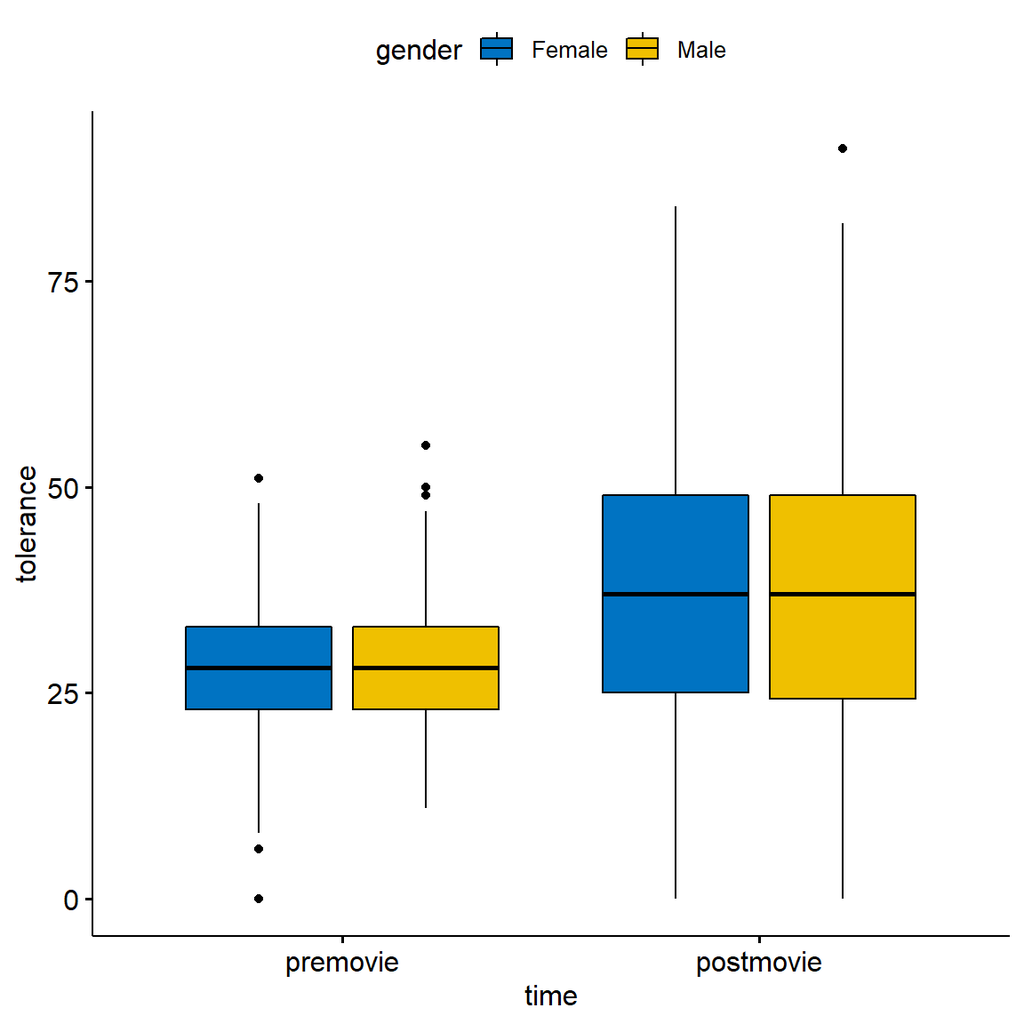

```r
ggboxplot(long_racism,
                 x = "time",
                 y = "tolerance",
                 fill = "gender",
                 palette = "jco")
```

The box plots also show that there are some outliers in some cells, later I will check if they are significant.

To see if I can continue with a parametric approach, I have to check some assumptions **in each cell**:

1. No significant outliers in any cell of the design.
2. Normality: the outcome (or dependent) variable should be approximately normally distributed in each cell of the design.
3. Homogeneity of variances: the variance of the outcome variable should be equal between the groups of the between-subjects factors.
4. Assumption of sphericity: the variance of the differences between within-subjects groups should be equal.
5. Homogeneity of covariances: the covariance matrices should be equal across the cells formed by the between-subjects factors.

Let’s start with checking the first assumption. From the previous boxplots we can see that there are some outliers. Are they significant?

```r
# check outliers
long_racism %>%
  group_by(time, gender) %>%
  identify_outliers(tolerance)
```

```
## # A tibble: 8 x 7
##   gender time      id    movie             tolerance is.outlier is.extreme
##   <fct>  <fct>     <fct> <fct>                 <dbl> <lgl>      <lgl>
## 1 Female premovie  4     To Kill A Mocking         0 TRUE       FALSE
## 2 Female premovie  84    12 Years a Slave          0 TRUE       FALSE
## 3 Female premovie  246   To Kill A Mocking        51 TRUE       FALSE
## 4 Female premovie  271   12 Years a Slave          6 TRUE       FALSE
## 5 Male   premovie  191   12 Years a Slave         50 TRUE       FALSE
## 6 Male   premovie  213   To Kill A Mocking        49 TRUE       FALSE
## 7 Male   premovie  275   12 Years a Slave         55 TRUE       FALSE
## 8 Male   postmovie 152   12 Years a Slave         91 TRUE       FALSE
```

There are 8 outliers, which are not extreme, so I will keep these units in the data set.

Now, let’s check if the outcome is normally distributed in each cell through qq-plots and Sahpiro-Wik tests:

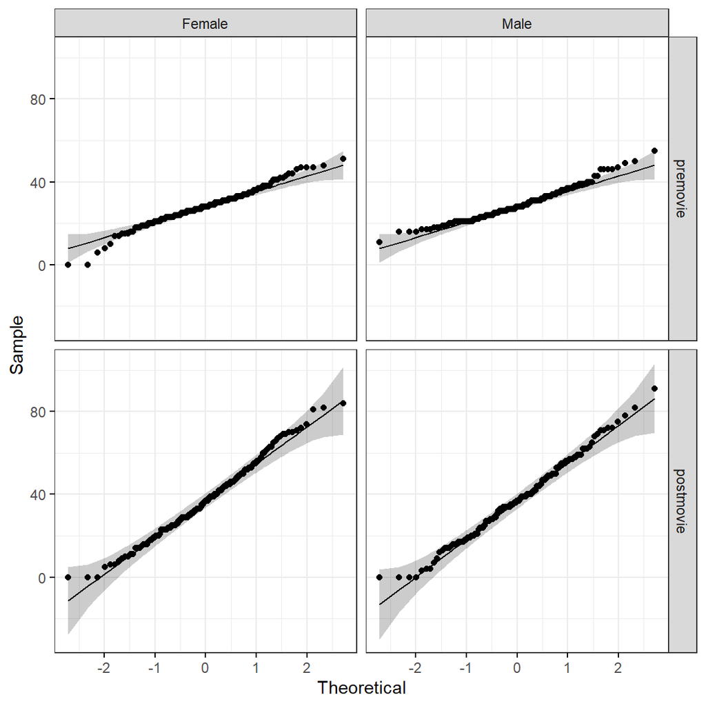

```r
# QQ-plots
ggqqplot(long_racism, "tolerance", ggtheme = theme_bw()) +
  facet_grid(time ~ gender)
```

```r
# Shapiro-Wik test
long_racism %>%
  group_by(time, gender) %>%
  shapiro_test(tolerance)
```

```
## # A tibble: 4 x 5
##   gender time      variable  statistic       p
##   <fct>  <fct>     <chr>         <dbl>   <dbl>
## 1 Female premovie  tolerance     0.981 0.0378
## 2 Male   premovie  tolerance     0.970 0.00218
## 3 Female postmovie tolerance     0.989 0.274
## 4 Male   postmovie tolerance     0.991 0.449
```

The normality assumption is not met in all the cells, but each cell contains more than 100 observations, so by the central limit theorem this should not cause so much problems.

Let’s check for homoscedasticity:

```r
# Homogeneity of variance of the between-subject factor (movie)
long_racism %>%
  group_by(time) %>%
  levene_test(tolerance ~ gender)
```

```
## # A tibble: 2 x 5
##   time        df1   df2 statistic     p
##   <fct>     <int> <int>     <dbl> <dbl>
## 1 premovie      1   298    0.455  0.500
## 2 postmovie     1   298    0.0423 0.837
```

The variance of the outcome variable *tolerance* is equal in the two genders.

```r
# Homogeneity of covariances of the between-subject factor (group)
box_m(long_racism[, "tolerance", drop = FALSE], long_racism$gender)
```

```
## # A tibble: 1 x 4
##   statistic p.value parameter method
##       <dbl>   <dbl>     <dbl> <chr>
## 1     0.127   0.722         1 Box's M-test for Homogeneity of Covariance Matric~
```

Only a p-value smaller than 0.001 is significant, so the null hypothesis is accepted.

The assumption of sphericity will be automatically checked during the computation of the ANOVA test.

```r
# Two-way mixed ANOVA test
res.aov <- anova_test(
  data = long_racism, dv = tolerance, wid = id,
  between = gender, within = time
)

get_anova_table(res.aov)
```

```
## ANOVA Table (type II tests)
##
##        Effect DFn DFd      F        p p<.05      ges
## 1      gender   1 298  0.079 7.79e-01       0.000145
## 2        time   1 298 65.758 1.34e-14     * 0.091000
## 3 gender:time   1 298  0.078 7.80e-01       0.000118
```